# 作业1-用户画像数据分析与可视化模板

### 作业2-用户画像数据分析

学号：2340624236

姓名：李茹汾

```python
import pandas as pd
import numpy as np
import matplotlib.pyplot as plt
import seaborn as sns
from pyecharts.charts import Pie, Bar
from pyecharts import options as opts
```

#### 1.背景设定：

你作为某旅游类电商平台（"TravelGo"）的运营数据分析师，面临以下业务问题：

- 用户流失加剧：近3个月高价值用户复购率下降15%
- 优惠券效果存疑：市场部质疑优惠券投放是否覆盖了大部分商品
- 内容策略调整：需要根据用户偏好优化APP首页内容推荐

```python
#读取数据（代码）
```

```python
# 设置中文显示
plt.rcParams['font.sans-serif'] = ['SimHei']# 让图表认得中文
plt.rcParams['axes.unicode_minus'] = False # 让图表认得负号
sns.set_theme(font='SimHei', style='whitegrid')#加上白色网格背景。

# 直接读取这个 Excel 文件，并用 sheet_name 指定读取哪张表
behavior_df = pd.read_excel('用户画像数据.xlsx', sheet_name='用户行为数据')
consume_df = pd.read_excel('用户画像数据.xlsx', sheet_name='消费记录数据')

# 打印读取成功提示
print("数据全部成功加载：")
print("用户行为数据形状：", behavior_df.shape)
print("消费记录数据形状：", consume_df.shape)
#.shape：这是表格的一个属性，意思是“形状”。它会告诉我们这张表有多少行、多少列。
#用户行为数据形状： (1000, 8) —— 意思就是这张表有 1000 行（1000个用户），8 列（性别、年龄、城市等）。
```

```
数据全部成功加载：
用户行为数据形状： (1000, 8)
消费记录数据形状： (2080, 7)
```

#### 2.数据清洗

##### 2.1.了解数据基本情况

```python
# 数据信息情况（代码）
```

```python
print("--- 用户行为数据基本信息 ---")
print(behavior_df.info())
print("\n--- 消费记录数据基本信息 ---")
print(consume_df.info())
```

[output not shown]

```python
print("\n--- 用户行为数据数值型描述统计 ---")
print(behavior_df.describe())
#.describe()：让机器人快速对所有“数字列”做一个综合统计描述。
# 它会瞬间算出：总数（count）、平均值（mean）、标准差（std）、最小值（min）、最大值（max）以及中位数（50%）。
```

```
--- 用户行为数据数值型描述统计 ---
                年龄         活跃天数   平均停留时长(秒)          点击率
count  1000.000000  1000.000000  950.000000  1000.000000
mean     30.740000    15.252000  119.970000     0.291210
std       7.809442     8.596301   38.864966     0.163793
min      18.000000     1.000000    5.800000     0.010000
25%      24.000000     8.000000   95.325000     0.160000
50%      31.000000    15.000000  120.950000     0.260000
75%      37.000000    23.000000  144.475000     0.390000
max      44.000000    29.000000  230.500000     0.950000
```

```python
print(behavior_df['点击率'].dtype)
```

```
float64
```

##### 2.2.处理缺失值

```python
#判断缺失值，如有缺失值应有相应处理（代码）
```

```python
# 判断缺失值
print("用户行为数据缺失值数量：\n", behavior_df.isnull().sum())
print("\n消费记录数据缺失值数量：\n", consume_df.isnull().sum())

#.isnull()：检查表格里每一个格子，“如果是空的，就举手（记为True/1）”。
#.sum()：把所有举手的人加起来。这样就能统计出每一列分别有多少个空格子。

# 如果存在缺失值，采用删除或填充策略
behavior_df = behavior_df.dropna(subset=['用户ID'])
consume_df = consume_df.dropna(subset=['订单ID'])
print("\n缺失值处理完成。")
```

[output not shown]

##### 2.3.处理异常值

```python
#处理异常值（代码）
```

```python
# 异常值规则：点击率高于 0.08 时属于异常数据，进行过滤处理
print(f"处理前点击率大于0.08的异常记录数: {len(behavior_df[behavior_df['点击率'] > 0.08])}")
#behavior_df['点击率'] > 0.08：这是个筛选条件，找出点击率大于 8% 的所有人。
#len(...)：length 的缩写，用来计算“有多少个”。
#整个句子的意思是：帮我数数点击率大于 0.08 的异常有多少个，并打印出来。

# 过滤异常值
behavior_df = behavior_df[behavior_df['点击率'] <= 0.08]
print(f"过滤后用户行为数据样本量: {behavior_df.shape[0]}")
#这是过滤操作。意思是：“把行为表里点击率小于或等于 0.08 的正常数据筛选出来，
# 然后覆盖倒回 behavior_df 抽屉里”。把那些大于 0.08 的异常行全扔了。
```

```
处理前点击率大于0.08的异常记录数: 930
过滤后用户行为数据样本量: 70
```

##### 2.3.消费数据验证

查看一下订单数据是否存在重复的

```python
#判断是否有重复值，如有进行处理（代码）
```

```python
# 检查订单数据是否存在重复
print(f"消费记录中总重复行数: {consume_df.duplicated().sum()}")
#.duplicated()：检查有没有哪几行是一模一样的重复拷贝。.sum() 把它加起来。
print(f"订单ID重复数量: {consume_df.duplicated(subset=['订单ID']).sum()}")

# 如有重复值，进行去重处理
consume_df = consume_df.drop_duplicates(subset=['订单ID'], keep='first')
print(f"去重后消费记录样本量: {consume_df.shape[0]}")
#.drop_duplicates(...)：扔掉重复项。
#subset=['订单ID']：以“订单ID”为准。如果出现了两个一模一样的订单ID，说明记录重复了。
#keep='first'：保留第一次出现的那个，把后面重复的删掉。
```

```
消费记录中总重复行数: 0
订单ID重复数量: 0
去重后消费记录样本量: 2080
```

##### 2.4.消费数据整理

将消费日期整理出消费年月，以分析复购率。如日期为2025-03-04，整理为202503。

```python
#处理消费日期（代码）
```

```python
# 将消费日期整理出消费年月，如将 2025-03-04 整理为 202503
consume_df['消费日期'] = pd.to_datetime(consume_df['消费日期'])
#pd.to_datetime(...)：“把这一列文本，正式转换成系统能听懂的‘标准日期时间格式’”，这样才能进行日期的加减和提取。
consume_df['消费年月'] = consume_df['消费日期'].dt.strftime('%Y%m')
#consume_df['消费年月'] =：表格右边本来没有这一列。这样写等于在表格最右边强行新加一列，名字叫“消费年月”。
#.dt.strftime('%Y%m')：dt 代表时间工具，strftime 意思是“把时间格式化为文本”。%Y 代表4位年份，%m 代表2位月份。

print("消费数据整理结果展示：")
print(consume_df[['用户ID', '消费日期', '消费年月']].head())
#.head()：默认只把表格的前 5 行拿出来给我们预览
```

```
消费数据整理结果展示：
    用户ID       消费日期    消费年月
0  U1695 2025-04-05  202504
1  U1695 2024-08-12  202408
2  U1695 2024-07-17  202407
3  U1913 2024-11-05  202411
4  U1913 2025-03-29  202503
```

#### 3.数据分析，针对分析目标找到相应数据支撑

3.1.复购率数据分析（主要针对消费信息表中的：用户编号、商品类别和消费日期）

```python
#复购率数据分析（数据分析及可视化代码）
#第一个痛点
```

```
--- 各品类月度复购率数据（前10行） ---
     消费年月  商品类别  总人数  复购人数       复购率
0  202405  当地玩乐   15   0.0  0.000000
1  202405  旅游套餐   42   1.0  0.023810
2  202405    机票   53   3.0  0.056604
3  202405    酒店   70   4.0  0.057143
4  202406  当地玩乐   14   0.0  0.000000
5  202406  旅游套餐   36   0.0  0.000000
6  202406    机票   46   0.0  0.000000
7  202406    酒店   72   5.0  0.069444
8  202407  当地玩乐   19   0.0  0.000000
9  202407  旅游套餐   35   0.0  0.000000
```

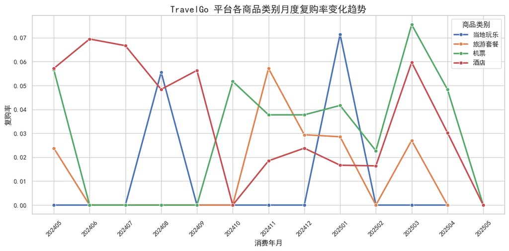

```python
# 1. 统计每个用户在每个年月、每个商品类别的购买次数
user_month_cate = consume_df.groupby(['消费年月', '商品类别', '用户ID']).size().reset_index(name='购买次数')
#groupby(['消费年月', '商品类别', '用户ID'])：这是最关键的“分类堆放”指令。

#把原始的消费记录表拿过来，按照这三个条件分成一堆一堆的。
#比如：【2024年5月 + 机票 + 张三】放在一堆，【2024年5月 + 机票 + 李四】放在另一堆。
#.size()：数一数【2024年5月 + 机票 + 张三】这一堆里有几张小票？
#如果是3张，说明张三在这个月买了3次机票。
#.reset_index(name='购买次数')：把数出来的结果做成一张漂亮的新表格，
# 给数量那一列起名叫“购买次数”，并把整张新表存进 user_month_cate 这个新抽屉里。


# 2. 统计各年月各品类的总购买人数（活跃买家数）
total_buyers = user_month_cate.groupby(['消费年月', '商品类别']).size().reset_index(name='总人数')
#把刚才第一步做好的那张表拿过来，把【2024年5月 + 机票】的所有人都归为一堆
# （不管张三、李四还是王五，只要是这个月买机票的，都在这一堆里）。
#.size()：再数数这一堆里有多少行。因为第一步里，每个人已经凝聚成了一行（比如张三只占一行），
# 所以这时候数出来的行数，恰好就是这个月买机票的总人数（不重复的总人数）。
#name='总人数'：把结果起名叫“总人数”，存入 total_buyers 抽屉。


# 3. 统计各年月各品类的复购人数（购买次数 >= 2）
repurchase_buyers = user_month_cate[user_month_cate['购买次数'] >= 2].groupby(['消费年月', '商品类别']).size().reset_index(name='复购人数')
#user_month_cate['购买次数'] >= 2：【条件筛选】 机器人先拿把筛子，把第一步那张表里，购买次数小于 2（也就是只买过 1 次）的人全部筛掉。
# 只留下那些买了 2 次、3 次、甚至更多次的老顾客。
#.groupby(['消费年月', '商品类别'])：【再次分组】 把这些留下来的老顾客，
# 按照【月份】和【品类】堆在一起。比如【2024年5月 + 机票】堆一堆。
#.size() / name='复购人数'：【数数命名】 数一数这一堆里有多少个老顾客，起名叫“复购人数”，存入 repurchase_buyers 抽屉。


# 4. 合并数据并计算复购率
repurchase_df = pd.merge(total_buyers, repurchase_buyers, on=['消费年月', '商品类别'], how='left').fillna(0)
#pd.merge(total_buyers, repurchase_buyers, ...)：把“总人数表”和“复购人数表”像 Excel 里的 VLOOKUP 一样拼起来。
#on=['消费年月', '商品类别']：按照月份和商品品类对齐。比如把 202405 的机票总人数，和 202405 的机票复购人数并排拼在一行。
#how='left'：以左边的“总人数表”为主。如果某个冷门品类当月有人买，但没有任何人复购，右边表里就会没有记录，就会在表格里留一个表示空值的 NaN。
#.fillna(0)：【打补丁】它把所有拼表产生的 NaN（空值）全部填上数字 0。意思是：没人复购，那复购人数就是 0 人。

repurchase_df['复购率'] = repurchase_df['复购人数'] / repurchase_df['总人数']
#做除法：在表格最右边强行新开一列叫“复购率”。
#计算公式：复购率 = 复购人数 ÷ 总人数。比如总共 100 个人买机票，有 20 个人买了 2 次以上，那复购率就是 20%。

print("--- 各品类月度复购率数据（前10行） ---")
print(repurchase_df.head(10))

# 5. 使用 Seaborn 进行多品类月度复购率趋势可视化
plt.figure(figsize=(12, 6))#铺一张长 12 英寸、宽 6 英寸的空白大画纸
sns.lineplot(data=repurchase_df, x='消费年月', y='复购率', hue='商品类别', marker='o', linewidth=2.5)
plt.title('TravelGo 平台各商品类别月度复购率变化趋势', fontsize=16)
plt.xlabel('消费年月', fontsize=12)
plt.ylabel('复购率', fontsize=12)
plt.xticks(rotation=45)
#rotation=45：rotation 意思是“旋转”。小刻度旋转
plt.tight_layout()#tight_layout：字面意思是“紧凑的布局”
plt.show()
```

3.2.优惠劵的投放情况

```
--- 优惠券各品类覆盖率统计 ---
是否使用优惠券    否    是    优惠券覆盖率
商品类别
当地玩乐     125   86  0.407583
旅游套餐     281  152  0.351039
机票       359  261  0.420968
酒店       490  326  0.399510
```

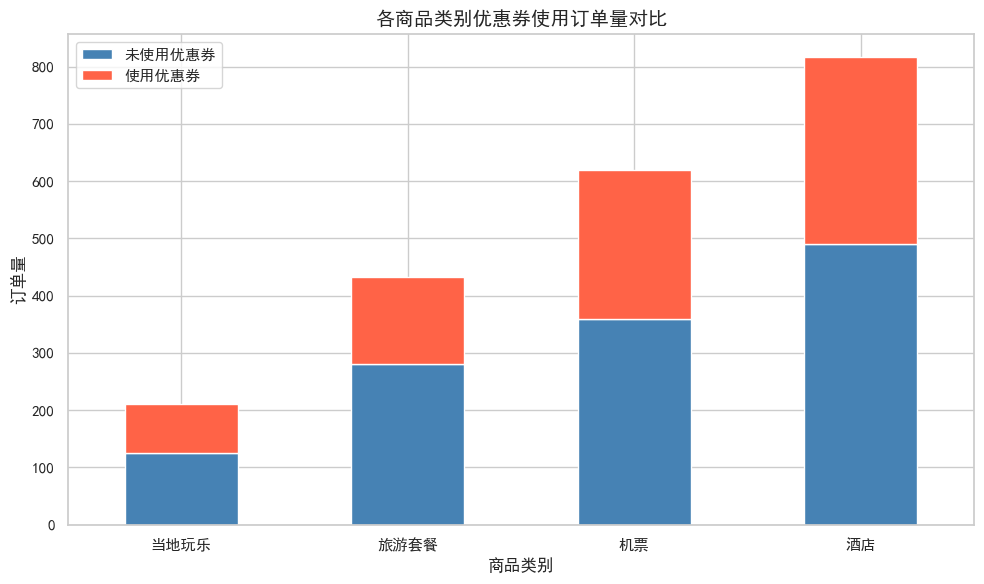

```python
#优惠卷投放情况（数据分析及可视化代码）

# 统计各品类下是否使用优惠券的订单量

coupon_analysis = consume_df.groupby(['商品类别', '是否使用优惠券']).size().unstack(fill_value=0)
#groupby(['商品类别', '是否使用优惠券'])：把消费表拿过来，先按“商品类别（机票/酒店等）”堆成一堆，再在里面按“是否使用优惠券（是/否）”分成更小的堆。
#.size()：数数每个小堆里有多少张订单。
#.unstack(fill_value=0)：unstack 叫“行转列（透视）”。
#默认算完的数据是长条形的，很难看。加上这句后，把数据扭转成一个像 Excel 交叉表一样的方块表。横行是“商品类别”，纵列是“是”和“否”。
#fill_value=0：如果某个品类（比如‘当地玩乐’）没有任何一单用过券，格子原本会是空的（NaN），这里指定用 0 填满。
coupon_analysis['优惠券覆盖率'] = coupon_analysis['是'] / (coupon_analysis['是'] + coupon_analysis['否'])
#算比例：在表格最右边新开一列，起名叫“优惠券覆盖率”。
#计算公式：用券单数（是） ÷ 总单数（是 + 否）。这就帮运营算出了每个品类的领券转化效果。
print("--- 优惠券各品类覆盖率统计 ---")
print(coupon_analysis)



# 1. 使用 Matplotlib 绘制品类优惠券使用对比条形图

coupon_analysis[['否', '是']].plot(kind='bar', stacked=True, figsize=(10, 6), color=['#4682B4', '#FF6347'])

plt.title('各商品类别优惠券使用订单量对比', fontsize=14)

plt.xlabel('商品类别', fontsize=12)

plt.ylabel('订单量', fontsize=12)

plt.legend(['未使用优惠券', '使用优惠券'])
#图例汉化。告诉看图的人，蓝色代表‘未使用优惠券’，红色代表‘使用优惠券’。
plt.xticks(rotation=0)
#rotation=0 意思是旋转角度为 0（字正着站立）。
# 因为“机票”、“酒店”只有两个字，非常短，不需要斜着躺，正着站就很好看。
plt.tight_layout()

plt.show()


# 2. 使用 Pyecharts 绘制优惠券整体投放品类分布饼图

coupon_yes = consume_df[consume_df['是否使用优惠券'] == '是'].groupby('商品类别').size().reset_index()

data_pair = [list(z) for z in zip(coupon_yes['商品类别'], coupon_yes[0].astype(int))]
#【打包行李】：Pyecharts ，它不直接认表格，它只认识一种特定的格式（叫列表对）。
#这行代码是用特殊的“打包手法”，把品类名字（比如机票）和对应的数字（比如100单）捆绑在一起，打包成一个叫 data_pair 的行李箱。
#打包完长这样：[['机票', 100], ['酒店', 200]...]


pie = (

    Pie()

    .add("", data_pair)
#.add("", data_pair)：把刚刚打包好的行李箱 data_pair 里的数据塞进饼图里。
    .set_global_opts(title_opts=opts.TitleOpts(title="优惠券订单在各品类中的分布比例"))
#.set_global_opts(...)：【全局配置】 设置整个大图的标题叫“优惠券订单在各品类中的分布比例”。
    .set_series_opts(label_opts=opts.LabelOpts(formatter="{b}: {c}单 ({d}%)"))
#.set_series_opts(...)：【特殊配置】 设置饼图表面上显示的文字格式（formatter）。
)
#这里的 {b}、{c}、{d} 是代称：
#{b} 代表名字（品类名，如‘机票’）；
#{c} 代表具体数量（多少单）；
#{d}% 代表百分比（占比）。
#连起来就是让饼图在每一块扇形旁边显示：机票: 100单 (25.0%)。
pie.render_notebook()
```

[output not shown]

```
--- 优惠券各品类覆盖率统计 ---
是否使用优惠券    否    是    优惠券覆盖率
商品类别
当地玩乐     125   86  0.407583
旅游套餐     281  152  0.351039
机票       359  261  0.420968
酒店       490  326  0.399510
```

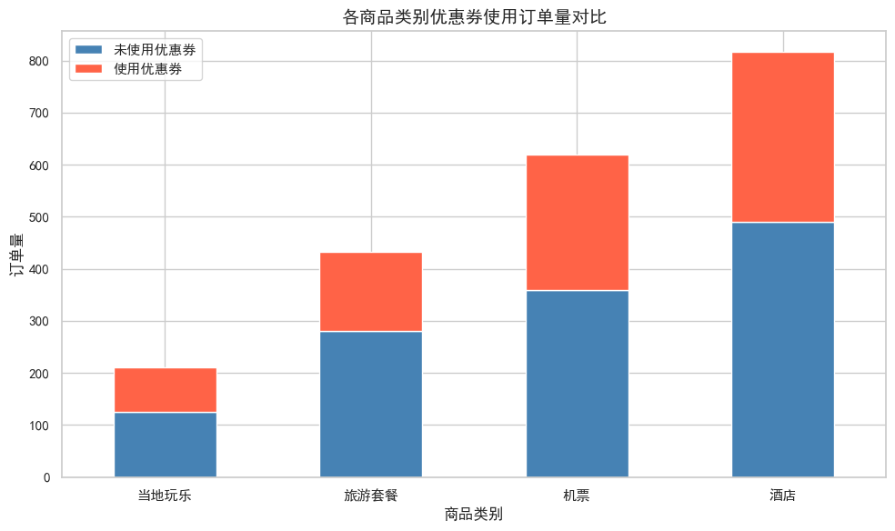

```python
# 统计各品类下是否使用优惠券的订单量
coupon_analysis = consume_df.groupby(['商品类别', '是否使用优惠券']).size().unstack(fill_value=0)
coupon_analysis['优惠券覆盖率'] = coupon_analysis['是'] / (coupon_analysis['是'] + coupon_analysis['否'])
print("--- 优惠券各品类覆盖率统计 ---")
print(coupon_analysis)

# 1. 使用 Matplotlib 绘制品类优惠券使用对比条形图
coupon_analysis[['否', '是']].plot(kind='bar', stacked=True, figsize=(10, 6), color=['#4682B4', '#FF6347'])
plt.title('各商品类别优惠券使用订单量对比', fontsize=14)
plt.xlabel('商品类别', fontsize=12)
plt.ylabel('订单量', fontsize=12)
plt.legend(['未使用优惠券', '使用优惠券'])
plt.xticks(rotation=0)
plt.tight_layout()
plt.show()

# 2. 使用 Pyecharts 绘制优惠券整体投放品类分布饼图
coupon_yes = consume_df[consume_df['是否使用优惠券'] == '是'].groupby('商品类别').size().reset_index()
data_pair = [list(z) for z in zip(coupon_yes['商品类别'], coupon_yes[0].astype(int))]

pie = (
    Pie()
    .add("", data_pair)
    .set_global_opts(title_opts=opts.TitleOpts(title="优惠券订单在各品类中的分布比例"))
    .set_series_opts(label_opts=opts.LabelOpts(formatter="{b}: {c}单 ({d}%)"))
)
pie.render_notebook()
```

[output not shown]

3.3.推送内容策略分析

```python
#推送内容情况分析（数据分析及可视化代码）
```

```
--- 推送内容核心指标分析 ---
   内容偏好       活跃天数   平均停留时长(秒)       点击率  受众用户数
0  旅行攻略  16.480000  118.334783  0.055600     25
1  时尚美妆  16.142857  103.800000  0.061429      7
2  科技数码  16.900000  110.531579  0.057000     20
3  美食探店  14.611111  120.060000  0.051111     18
```

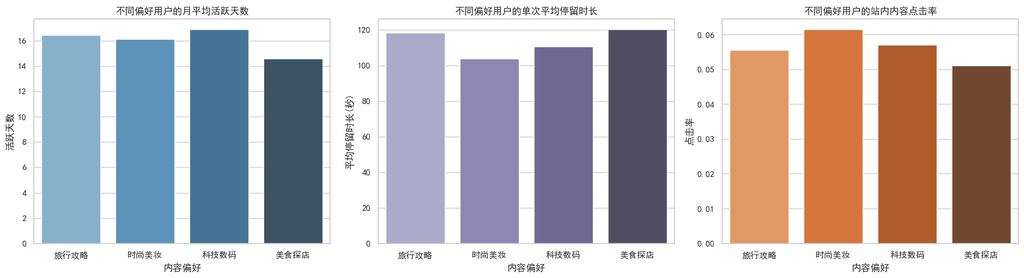

```python
# 按照内容偏好分组，计算行为指标的均值
content_strategy = behavior_df.groupby('内容偏好').agg({
    '活跃天数': 'mean',
    '平均停留时长(秒)': 'mean',
    '点击率': 'mean',
    '用户ID': 'count'
}).rename(columns={'用户ID': '受众用户数'}).reset_index()
#groupby('内容偏好')：先把用户按爱好分类。喜欢看“旅行攻略”的站一堆，喜欢“美食探店”的站一堆，喜欢“科技数码”的站一堆。
#.agg({ ... })：agg 是 Aggregate（聚合） 的缩写。以前我们只能算单项（比如 .sum() 或 .mean()），用 .agg 就可以针对不同的列下达不同的计算命令：
#'活跃天数': 'mean'：帮我算算这堆人月平均活跃天数的平均值（mean）。
#'平均停留时长(秒)': 'mean'：算算他们每次在 APP 逛多久的平均值。
#'点击率': 'mean'：算算他们的平均广告点击率。
#'用户ID': 'count'：顺便帮我数一数（count）喜欢这个爱好的总共有多少人。
#.rename(columns={'用户ID': '受众用户数'})：改名。刚才数出来的用户ID数量其实就是“人数”，把它重命名（rename）为“受众用户数”，这样看表格的人一目了然。
#.reset_index()：让计算出来的结果重新变成一张规规矩矩的扁平表格，起名叫 content_strategy。
print("--- 推送内容核心指标分析 ---")
print(content_strategy)

# 使用 Seaborn 绘制多变量画布
fig, axes = plt.subplots(1, 3, figsize=(18, 5))
#plt.subplots(1, 3, ...)：绘制子图（subplots）。
#括号里的 1, 3 代表【1 行，3 列】。
#“在桌面上给我铺一张巨大的画纸，并在上面切出三个并排的房间（小方格）”。

sns.barplot(data=content_strategy, x='内容偏好', y='活跃天数', ax=axes[0], palette='Blues_d')
axes[0].set_title('不同偏好用户的月平均活跃天数')

sns.barplot(data=content_strategy, x='内容偏好', y='平均停留时长(秒)', ax=axes[1], palette='Purples_d')
axes[1].set_title('不同偏好用户的单次平均停留时长')

sns.barplot(data=content_strategy, x='内容偏好', y='点击率', ax=axes[2], palette='Oranges_d')
axes[2].set_title('不同偏好用户的站内内容点击率')
#axes 是个行李箱，里面装了三个房间的钥匙，
# 分别叫 axes[0]（左边第一个房）、axes[1]（中间第二个房）、axes[2]（右边第三个房）。
plt.tight_layout()
plt.show()
```

3.4.扩展分析 高消费用户（top 20%）的内容偏好分析

```python
#高消费用户的内容分析（数据分析及可视化代码）
```

```
Top 20% 高消费用户入围门槛为累计消费：800.00元，高价值用户共：141人

--- Top 20% 高消费用户的内容偏好分布 ---
   内容偏好  高价值用户数        占比
0  旅行攻略       1  0.166667
1  科技数码       3  0.500000
2  美食探店       2  0.333333
```

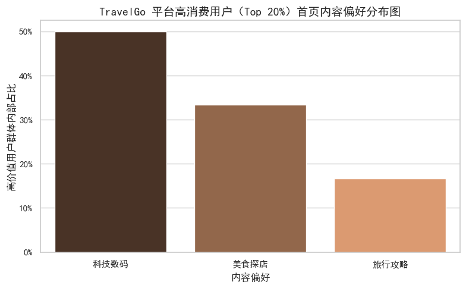

```python
# 1. 计算每个用户的累计消费总额
user_spend = consume_df.groupby('用户ID')['消费金额(元)'].sum().reset_index()
#groupby('用户ID')：机器人来到消费记录表，把所有小票按用户堆成一堆。张三的小票一堆，李四的一堆。
#['消费金额(元)'].sum()：sum 是求和。机器人把张三这堆小票上的“消费金额”全部加起来，算出张三总共在平台花了多少钱。
#.reset_index()：重新整理成一张干净的“会员账单表”，起名叫 user_spend。
#表格里长这样：【张三，累计消费5000元】、【李四，累计消费200元】。

# 2. 划定 Top 20% 高消费用户的金额阈值
threshold = user_spend['消费金额(元)'].quantile(0.80)
#.quantile(0.80)：分位数函数，这是找财富分界线的黑科技。
#把所有人按照累计消费金额，从低到高排成一条长队。
#quantile(0.80) 意思是：走到队伍 80% 的位置，看看那个人的钱包里有多少钱。这个金额就是 threshold（门槛线/阈值）。
#比如门槛是 3000 元，意味着只有消费超过 3000 元的人，才能排进前 20% 的富豪榜。
top_20_users = user_spend[user_spend['消费金额(元)'] >= threshold]
#用这根门槛线当筛子，把所有消费大于等于门槛金额的土豪挑出来，存进 top_20_users（高价值用户表）中。
print(f"Top 20% 高消费用户入围门槛为累计消费：{threshold:.2f}元，高价值用户共：{len(top_20_users)}人")

# 3. 与用户行为偏好表进行 Inner Merge 联动
top_20_profile = pd.merge(top_20_users, behavior_df, on='用户ID', how='inner')
#把“土豪表”和“行为表”并排拼在一起，按照“用户ID”对齐。
#how='inner'（内连接）就像是一把严格的锁：必须这个人既在土豪表里（是VIP），又在行为表里（有干净的行为记录），才保留下来。
#拼完后的 top_20_profile 表里，就同时拥有了这群 VIP 的消费金额、性别、年龄、以及他们最爱看的“内容偏好”。

# 4. 统计高价值用户的内容偏好分布比例
top_20_content = top_20_profile.groupby('内容偏好').size().reset_index(name='高价值用户数')
top_20_content['占比'] = top_20_content['高价值用户数'] / top_20_content['高价值用户数'].sum()
#新开一列叫“占比”。公式是：该偏好的土豪人数 ÷ 土豪总人数。
print("\n--- Top 20% 高消费用户的内容偏好分布 ---")
print(top_20_content)

# 5. 可视化高价值用户偏好
plt.figure(figsize=(8, 5))
sns.barplot(data=top_20_content.sort_values(by='占比', ascending=False), x='内容偏好', y='占比', palette='copper')
plt.title('TravelGo 平台高消费用户（Top 20%）首页内容偏好分布图', fontsize=14)
plt.ylabel('高价值用户群体内部占比')
plt.gca().yaxis.set_major_formatter(plt.FuncFormatter(lambda y, _: '{:.0%}'.format(y)))
#这一行是高端格式化黑科技！ * 默认情况下，纵坐标轴显示的数字是小数（比如 0.1、0.2、0.3），在 PPT 汇报里看起来不够直观。
#这行代码是强行命令：“把纵坐标轴的数字，全部自动乘以 100 并且加上百分号（%），也就是把 0.45 变成 45% 显示出来！”
plt.tight_layout()
plt.show()
```